# Assignment 2: Analysis about Electricity Market Prices

Fatma Nur Dumlupınar

08.18.2020

## Loading Required Packages

Data source : [EPIAS/EXIST MCP/SMP Page](https://rapor.epias.com.tr/rapor/xhtml/ptfSmfListeleme.xhtml)

Data about electricity market prices was downloaded from the page above only for the month July.

```r
library(lubridate)
library(tidyr)
library(tidyverse)
library(ggplot2)
library(dplyr)
```

## Reading and Editing Data

```r
energy_prices <- read.csv("ptf-smf.csv", sep=",")

glimpse(energy_prices)
```

```
## Rows: 744
## Columns: 6
## $ Tarih                               <chr> "01.07.20 00:00", "01.07.20 01:...
## $ PTF                                 <chr> "323,85", "326,95", "324,31", "...
## $ SMF                                 <chr> "211,00", "201,00", "211,00", "...
## $ Pozitif.Dengesizlik.Fiyatı..TL.MWh. <chr> "204,67", "194,97", "204,67", "...
## $ Negatif.Dengesizlik.Fiyatı..TL.MWh. <chr> "333,57", "336,76", "334,04", "...
## $ SMF.Yön                             <chr> "?Enerji Fazlası", "?Enerji Faz...
```

```r
##Changing data types from 'char' to related ones

#Arranging decimal number, replacing points with commas
#from char to numeric
energy_prices$PTF<-as.numeric(gsub(",", ".", gsub("\\.", "", energy_prices$PTF)))
energy_prices$SMF<-as.numeric(gsub(",", ".", gsub("\\.", "", energy_prices$SMF)))
energy_prices$Pozitif.Dengesizlik.Fiyatı..TL.MWh.<-as.numeric(gsub(",", ".", gsub("\\.", "", energy_prices$Pozitif.Dengesizlik.Fiyatı..TL.MWh.)))
energy_prices$Negatif.Dengesizlik.Fiyatı..TL.MWh.<-as.numeric(gsub(",", ".", gsub("\\.", "", energy_prices$Negatif.Dengesizlik.Fiyatı..TL.MWh.)))

#from char to date-time
energy_prices$Tarih<-as.POSIXct(energy_prices$Tarih,format="%d.%m.%Y %H:%M")

#from char to factor
energy_prices$SMF.Yön<-as.factor(energy_prices$SMF.Yön)
```

## 1. Weekly Comparison of Prices

### Creating a new data frame

It can be reasonable to look at the weeks of July to see how much prices are in in each five weeks. Then, it will be possible to interpret the relationship between difference value `PTF-SMF` and the week number.

For this purpose, `Week` numbers are created using the date-time object `Tarih` and the data is grouped by `Week` to get weekly price values.

```r
weekly_prices<-energy_prices%>%
  select(Tarih,PTF,SMF,SMF.Yön,
         Negatif.Dengesizlik.Fiyatı..TL.MWh.,
         Pozitif.Dengesizlik.Fiyatı..TL.MWh.)%>%
  mutate(Week=as.factor(week(Tarih)))%>%
  pivot_longer(.,cols = c(PTF,SMF,
                          Pozitif.Dengesizlik.Fiyatı..TL.MWh.,
                          Negatif.Dengesizlik.Fiyatı..TL.MWh.),
               names_to = "names",
               values_to = "values") %>%
  group_by(Week,names)%>%
  summarise(sum_price=sum(values),mean_price=mean(values))%>%
  transform(Week=as.numeric(Week))

glimpse(weekly_prices)
```

```
## Rows: 20
## Columns: 4
## $ Week       <dbl> 1, 1, 1, 1, 2, 2, 2, 2, 3, 3, 3, 3, 4, 4, 4, 4, 5, 5, 5, 5
## $ names      <chr> "Negatif.Dengesizlik.Fiyatı..TL.MWh.", "Pozitif.Dengesiz...
## $ sum_price  <dbl> 56177.97, 45287.71, 50296.42, 50933.68, 51405.05, 40423....
## $ mean_price <dbl> 334.3927, 269.5697, 299.3835, 303.1767, 305.9824, 240.61...
```

### Data Visualization

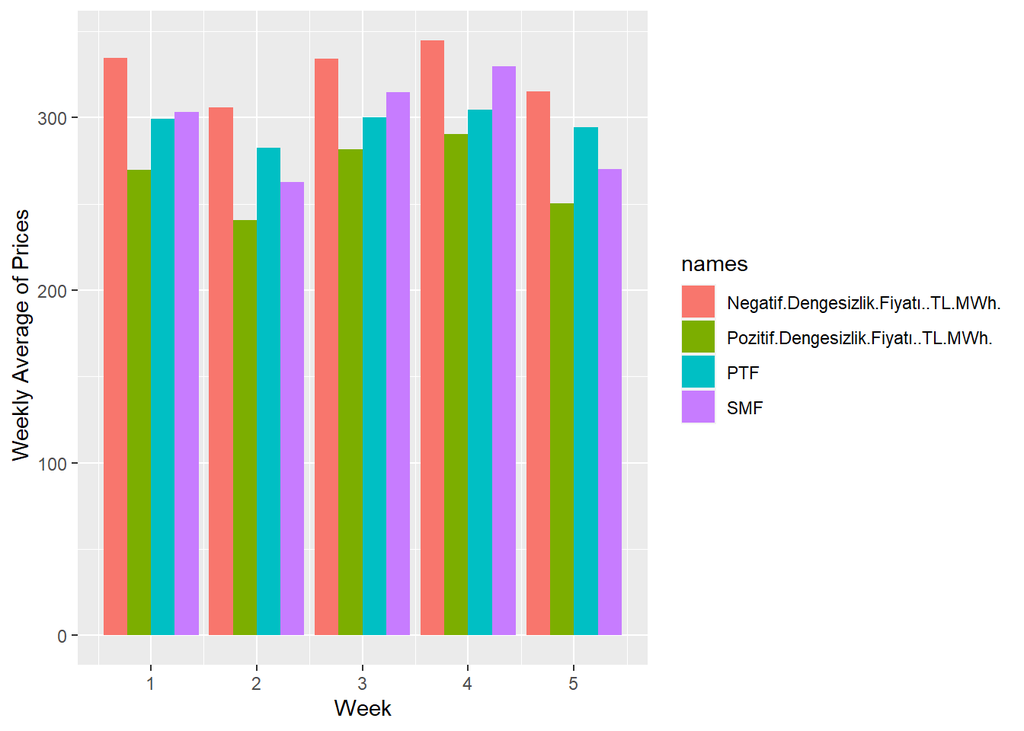

```r
ggplot(weekly_prices,aes(x=Week, y = mean_price, fill = names)) +
  geom_col(position="dodge")+
  labs(y=" Weekly Average of Prices")
```

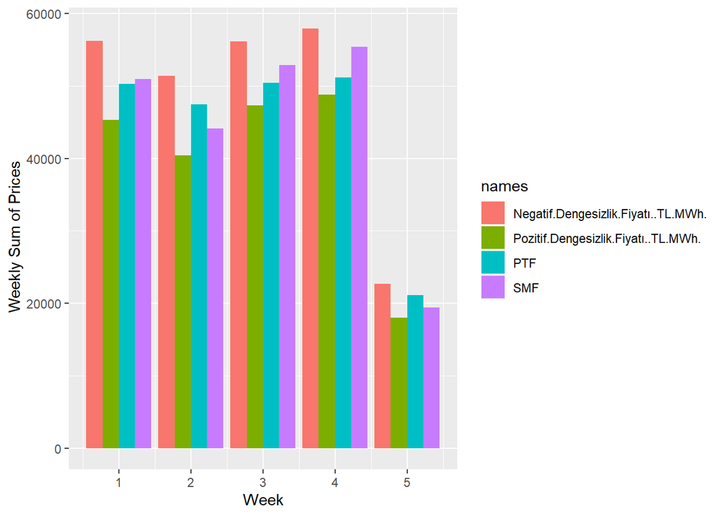

```r
ggplot(weekly_prices,aes(x=Week, y = sum_price, fill = names)) +
  geom_col(position="dodge")+
  labs(y=" Weekly Sum of Prices")
```

## 2. Overview to the Distribution of Prices

### Creating new data frame

An overview of the data can be useful for gaining insight into the distribution of variables’ values. For this, collecting the data under a heading will make it easier while visualizing.

```r
overall<-energy_prices%>%
  select(Tarih,PTF,SMF,
                Negatif.Dengesizlik.Fiyatı..TL.MWh.,
                Pozitif.Dengesizlik.Fiyatı..TL.MWh.)%>%
  pivot_longer(.,cols = c(PTF,SMF,
                        Pozitif.Dengesizlik.Fiyatı..TL.MWh.,
                        Negatif.Dengesizlik.Fiyatı..TL.MWh.),
             names_to = "names",
             values_to = "values")%>%
  transform(names=as.factor(names))
```

### Data Visualization

Color aesthetics is assigned to `names` so that the price data can be observed with different color for different type of price.

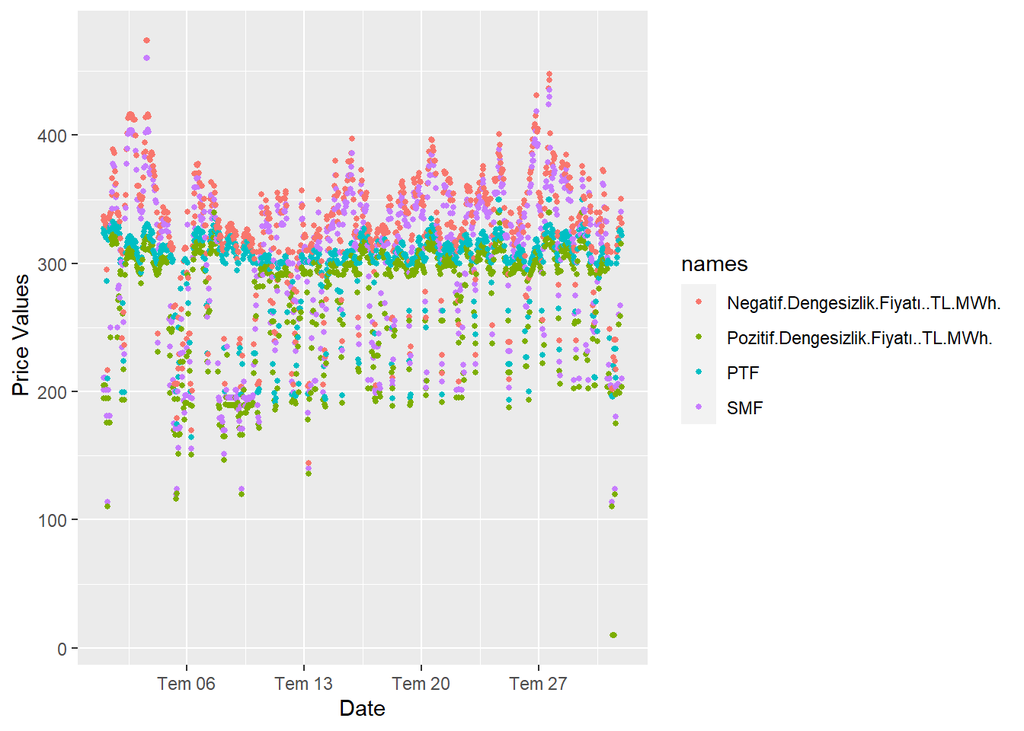

```r
ggplot(overall,aes(x=Tarih,y=values,color=names))+
  geom_point(size=1)+
  labs(x="Date",y=" Price Values")
```

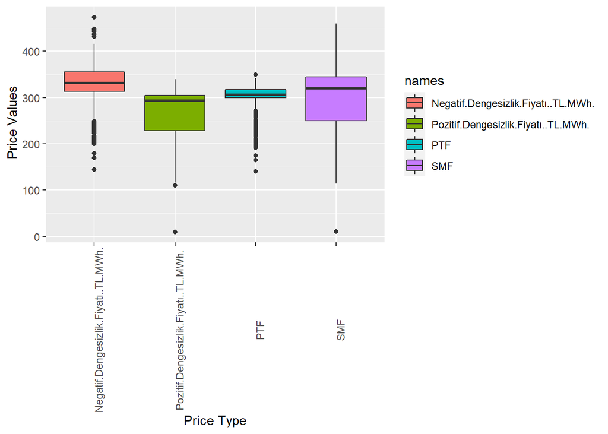

```r
ggplot(overall)+
  geom_boxplot(aes(x=names,y=values,fill=names))+
  theme(axis.text.x = element_text(angle = 90))+
  labs(x="Price Type",y=" Price Values")
```

From the scatter plot, it is possible to say most of the price data lie above 300 and fluctuations occur in the variables `SMF`, `Negatif.Dengesizlik.Fiyatı..TL.MWh.` at most

## 3. Hourly Track of Average Prices in a Day

### Creating new data frame

Seeing the hourly track of prices during a day will help further comment on the energy market. So, the price data are grouped by `Hour` and summarized by finding hourly average values.

```r
mean_by_hour<-energy_prices%>%
  select(PTF,SMF,Tarih,SMF.Yön,
         Negatif.Dengesizlik.Fiyatı..TL.MWh.,
         Pozitif.Dengesizlik.Fiyatı..TL.MWh.)%>%
  mutate(Hour=hour(Tarih))%>%
  group_by(Hour)%>%
  summarise(mean(PTF),mean(SMF),
            mean(Negatif.Dengesizlik.Fiyatı..TL.MWh.),
            mean(Pozitif.Dengesizlik.Fiyatı..TL.MWh.))%>%
  rename(mean_PTF='mean(PTF)',mean_SMF='mean(SMF)',
         mean_pozitifdengesizlikfiyatı='mean(Pozitif.Dengesizlik.Fiyatı..TL.MWh.)',
         mean_negatifdengesizlikfiyatı='mean(Negatif.Dengesizlik.Fiyatı..TL.MWh.)')
```

### Data Visualization

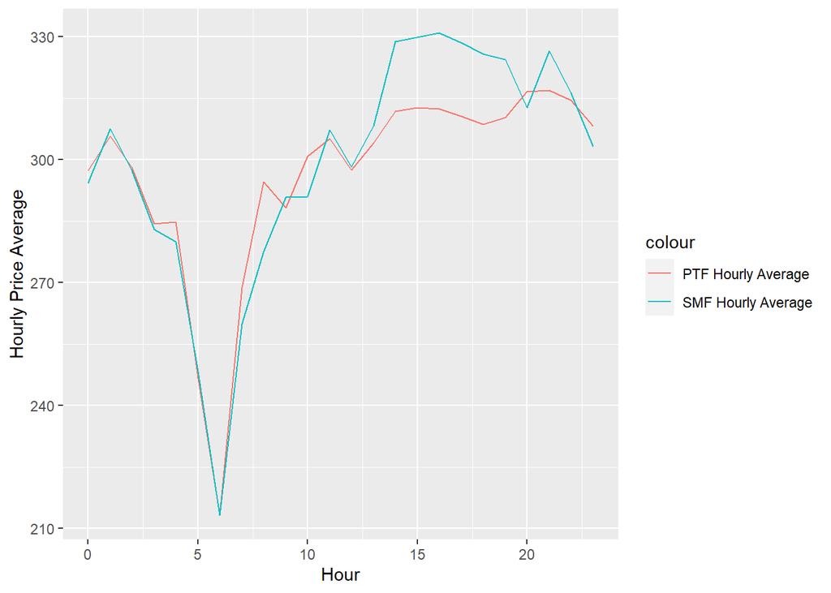

```r
ggplot(mean_by_hour) +
  geom_line(aes(y = mean_PTF,x=Hour, color = "PTF Hourly Average")) +
  geom_line(aes(y = mean_SMF,x=Hour, color = "SMF Hourly Average"))+
  labs(x="Hour",
       y="Hourly Price Average")
```

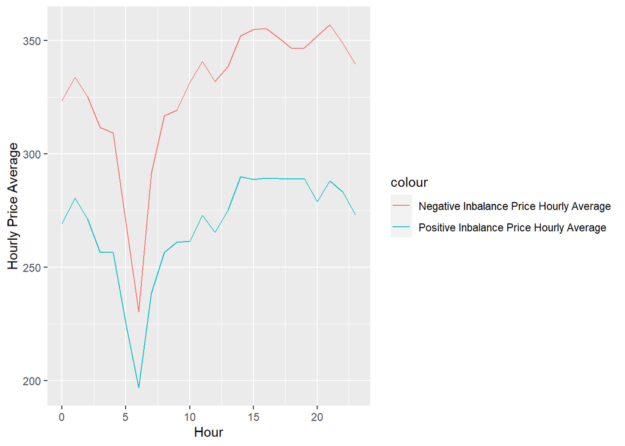

```r
ggplot(mean_by_hour) +
  geom_line(aes(y = mean_pozitifdengesizlikfiyatı,x=Hour, color = "Positive Inbalance Price Hourly Average")) +
  geom_line(aes(y = mean_negatifdengesizlikfiyatı,x=Hour, color = "Negative Inbalance Price Hourly Average"))+
  labs(x="Hour",
       y="Hourly Price Average")
```

The fluctuations within a day can be evaluated in general manner thanks to the average values.

From the first line plot, it is obvious that there is no a big difference between the values `SMF` and `PTF` in the time range 0-12, which indicates the estimation is successful. After that, the difference gets high.

From the second line plot, it is clear that the patterns of the lines are pretty similar but with different price values. They both see the lowest values after 4 am like `PTF` and `SMF` do in the previous plot.

## 4. Relationship between Price Difference and Energy Balance

### Creating new data frame

A new data.frame is needed to see the relationship between whether the difference value `PTF-SMF` is positive or negative, and the `SMF.Yön`.

```r
difference<-energy_prices%>%
  select(PTF,SMF,Tarih,SMF.Yön,
         Negatif.Dengesizlik.Fiyatı..TL.MWh.,
         Pozitif.Dengesizlik.Fiyatı..TL.MWh.)%>%
  mutate(diff=PTF-SMF)
```

### Data Visualization

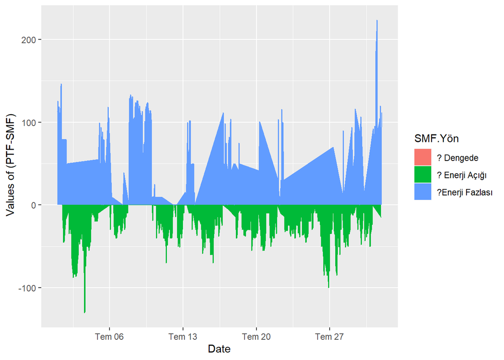

```r
ggplot(difference) +
  geom_area(aes(y = diff,x=Tarih, color=SMF.Yön, fill=SMF.Yön))+
  labs(x="Date", y=" Values of (PTF-SMF)")
```

It is seen that color of all the positive values of `PTF-SMF` is blue, which means “Energy Surplus”. Similarly, color of all the negative values is green, which means “Energy Deficit”. Therefore the plot confirms that if `PTF` is greater than `SMF`, actual demand is lower than predicted demand. If the situation is opposite, it is called “Energy Deficit”.

## 5. Hourly and Weekly Comparison of Difference Values

### Creating data frame

For further analysis about quality of the estimation in the market, difference values `PTF-SMF` can be examined hourly and weekly with the average values. So, the data is grouped by `Hour` and `Week`.

```r
difference_by_hour<-difference%>%
  mutate(diff=PTF-SMF,Hour=hour(Tarih))%>%
  group_by(Hour)%>%
  summarise(mean_diff_PTF_SMF=mean(diff))


difference_by_week<-difference%>%
  mutate(diff=PTF-SMF,Week=as.factor(week(Tarih)))%>%
  group_by(Week)%>%
  summarise(mean_diff_PTF_SMF=mean(diff))%>%
  transform(Week=as.numeric(Week))
```

### Data Visualization

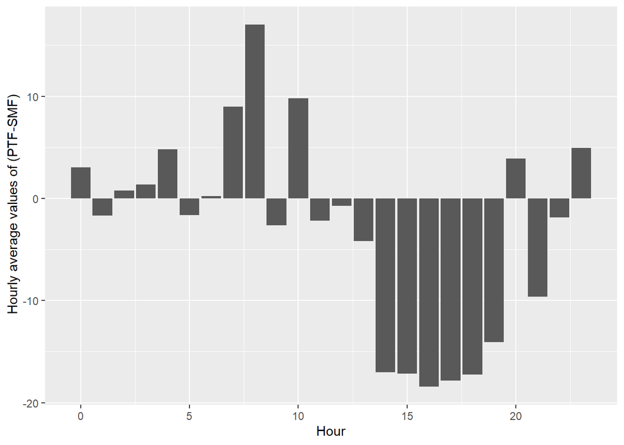

```r
ggplot(difference_by_hour) +
  geom_col(aes(y =mean_diff_PTF_SMF ,x=Hour))+
  labs(y=" Hourly average values of (PTF-SMF)")
```

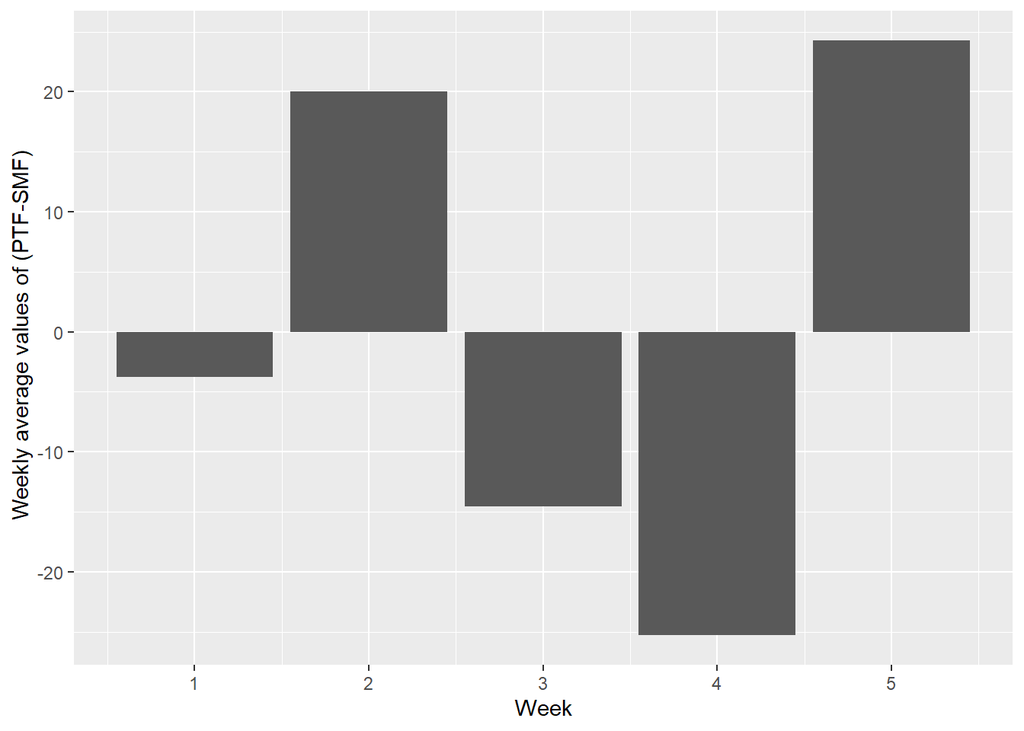

```r
ggplot(difference_by_week) +
  geom_col(aes(y =mean_diff_PTF_SMF ,x=Week))+
    labs(y=" Weekly average values of (PTF-SMF)")
```